# Reproducible Research: Peer Assessment 1

This document analyses data from a personal activity monitoring device. This device collects data at 5 minute intervals through out the day. The data consists of two months of data from an anonymous individual collected during the months of October and November, 2012 and include the number of steps taken in 5 minute intervals each day.

## Loading and preprocessing the data

Dplyr package will be used for efficient data frame modifications.  
Analysis uses the activity monitoring dataset available from https://d396qusza40orc.cloudfront.net/repdata%2Fdata%2Factivity.zip.

```r
    data <- read.csv("activity.csv")
```

## What is mean total number of steps taken per day?

We start analysis by calculating mean and median of total steps per day. We also display histogram of total steps per day.

Following code uses loaded activity dataset, calculates total steps per day and displays histogram. Dplyr package is used for efficient data frame manipulation.

```r
    ## Load dplyr package
    library(dplyr)
```

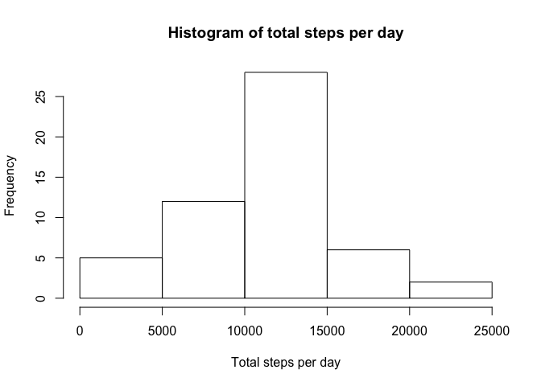

```r
    ## Create table showing steps per day and calculate total
    date_data = group_by(data, date)
    steps_per_day <- summarise(date_data, total = sum(steps))

    ## print histogram showing steps per day
    hist (steps_per_day$total, main="Histogram of total steps per day", xlab = "Total steps per day")
```

Next we calculate mean and median for total steps per day.

```r
    ## Calculate mean
    mean <- mean(steps_per_day$total, na.rm = TRUE)
    sprintf("Mean steps per day: %s", mean)
```

```
## [1] "Mean steps per day: 10766.1886792453"
```

```r
    ## Calculate median
    median <- median(steps_per_day$total, na.rm = TRUE)
    sprintf("Median steps per day: %s", median)
```

```
## [1] "Median steps per day: 10765"
```

## What is the average daily activity pattern?

Next we calculate average steps per intervals and find time interval with highest average.

Following code calculates average steps per time interval and displays it as line plot.

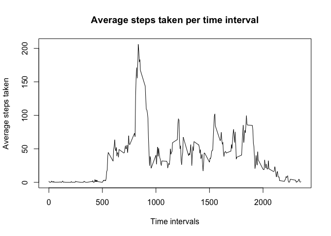

```r
    ## Create table showing average steps per interval
    interval_data = group_by(data, interval)
    average_per_interval <- summarise(interval_data, average = mean(steps, na.rm = TRUE))

    ## create plot
    plot(average_per_interval$interval, average_per_interval$average, type = "l", xlab = "Time intervals",
         ylab = "Average steps taken", main = "Average steps taken per time interval")
```

Next we find the time interval with highest average steps.

```r
    ## Find highest average time interval
    max_avg <- max(average_per_interval[,2])
    max_int <- average_per_interval[average_per_interval$average == max_avg, "interval"]
    sprintf("Interval containing highest average steps is: %s", max_int)
```

```
## [1] "Interval containing highest average steps is: 835"
```

## Imputing missing values

Next we analyse impact of missing values in the activity dataset. We will create new dataset where we replace missing values with average values per time interval. Then we create histogram of total steps per day and provide number of missing values replaced. Finally we calculate mean and median with missing values replaced and compare compare results to earlier results where missing values were removed.

Following code replaces missing values with time interval averages, calculates daily totals and displays histogram.

```r
    ## Replace missing values within time intervals using averages calculated earlier
    newdata <- data
    missing_values <- 0
    for(i in 1:nrow(newdata)) {
        if(is.na(newdata[i, "steps"])) {
            missing_values <- missing_values + 1
            interval <- newdata[i, "interval"]
            average <- average_per_interval[average_per_interval$interval == interval, "average"]
            newdata[i, "steps"] <- average
        }
    }

    sprintf("Number of missing values in dataset: %s", missing_values)
```

```
## [1] "Number of missing values in dataset: 2304"
```

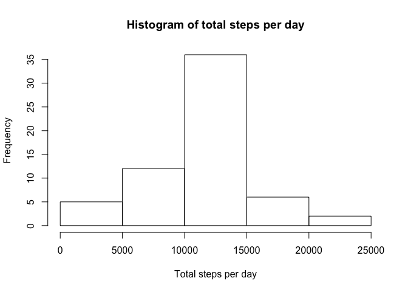

```r
    ## Create table showing steps per day
    date_data2 = group_by(newdata, date)
    steps_per_day2 <- summarise(date_data2, total = sum(steps))

    ## print histogram showing steps per day
    hist (steps_per_day2$total, main="Histogram of total steps per day", xlab = "Total steps per day")
```

Next we calculate mean and median.

```r
    ## Calculate mean
    mean2 <- mean(steps_per_day2$total)
    sprintf("Mean steps per day with missing values replaced: %s", mean2)
```

```
## [1] "Mean steps per day with missing values replaced: 10766.1886792453"
```

```r
    ## Calculate median
    median2 <- median(steps_per_day2$total)
    sprintf("Median steps per day with missing values replaced: %s", median2)
```

```
## [1] "Median steps per day with missing values replaced: 10766.1886792453"
```

## Are there differences in activity patterns between weekdays and weekends?

In this part we compare average internval step amounts on weekdays and weekends. First we calculate interval averages for weekdays and weekdays and then display plot showing both.

Following code creates new factor to show either weekday or weekend and then calculates interval averages for these factors on each interval.

```r
    ## Create new factor day and set its value to weekday or weekend
    newdata$day <- factor(NA, levels=c("weekday", "weekend"))
    for(i in 1:nrow(newdata))
    {
        day_of_week = weekdays(as.Date(newdata[i, "date"]))
        if (day_of_week %in% c("Monday", "Tuesday", "Wednesday", "Thursday", "Friday"))
            newdata[i, "day"] <- "weekday"
        else
            newdata[i, "day"] <- "weekend"
    }
    ## Calculate interval averages for weekdays
    weekday_data <- newdata[newdata$day == "weekday", ]
    weekday_interval = group_by(weekday_data, interval)
    weekday_average_per_interval <- summarise(weekday_interval, average = mean(steps), day = "weekday")
    ## Calculate interval averages for weekends
    weekend_data <- newdata[newdata$day == "weekend", ]
    weekend_interval = group_by(weekend_data, interval)
    weekend_average_per_interval <- summarise(weekend_interval, average = mean(steps), day = "weekend")
    ## Combine datasets for plotting
    combined_data <- rbind(weekday_average_per_interval, weekend_average_per_interval)
```

Next we plot the interval average result on weekends and weekdays using lattice package.

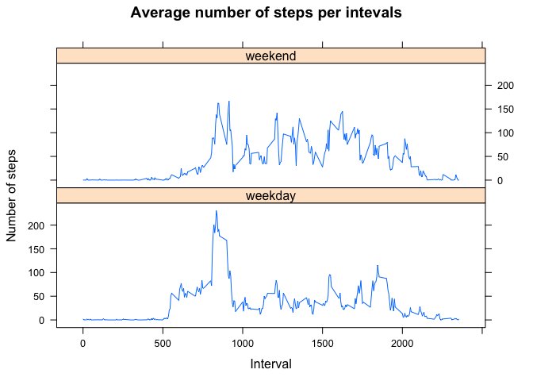

```r
    ## Use lattice library for drawings
    library(lattice)

    ## Create plot displaying both weekdays & weekends
    xyplot(average ~ interval | day,
           combined_data,
           main="Average number of steps per intevals", ylab="Number of steps",
           xlab="Interval", layout=c(1,2), type="l")
```